# Non Linear Recovery

David Champredon

August 25, 2016

## Background

The variable $I$ is the prevalence, expressed as a proportion of the total population (hence between 0 and 1). We want to understand the effect of a non-linear recovery on both the infectious duration distribution and also on the generation interval distributions.

We write the new dynamical system as
$$\frac{dI}{dt} = \beta SI - \gamma K(I) I$$
where $K$ is a non-negative continous function on [0;1].

See DE’s notes for an analytical exploration. Here we focus on a numerical exploration.

## Epidemiological Model

An agent-based model is used to explore the effect of non-linear recovery. The model is a stochastic $SE_mI_nR$ compartmental model implemented with a tau-leap algorithm (there is the possibility to run with an exact Gillespie algorithm, but it is very slow). The only information that is tracked at the indivdual level is the time of infection, the time of disease transmission to another individual, the time infectiousness starts and ends. The first two times give the generation interval distributions, the last two the infectious duration one.

The code is written in C++ and wrapped in a R library.

## Implemented $K$ functions

For now, six functions are implemented in the code.

| Function name | Formula |
| --- | --- |
| `one` | $K(I) = 1$ |
| `lin` | $K(I) = I$ |
| `sqrt` | $K(I) = \sqrt{I}$ |
| `exp` | $K(I) = \exp{\left(-aI\right)}$ |
| `inv` | $K(I) = 1 / (a+bI)$ |
| `pow` | $K(I) = I^{a-1}$ |

Some names are redundant (e.g. `lin` could be expressed as `pow`) but that makes labelling easier.

## Basic consistency checks

First of all, let’s check there are no obvious implementation errors. The ABM with $K(I)=1$ is compared with both an ODE SIR model solved with `lsoda` and a stochastic SIR model using the `adaptivetau` package.

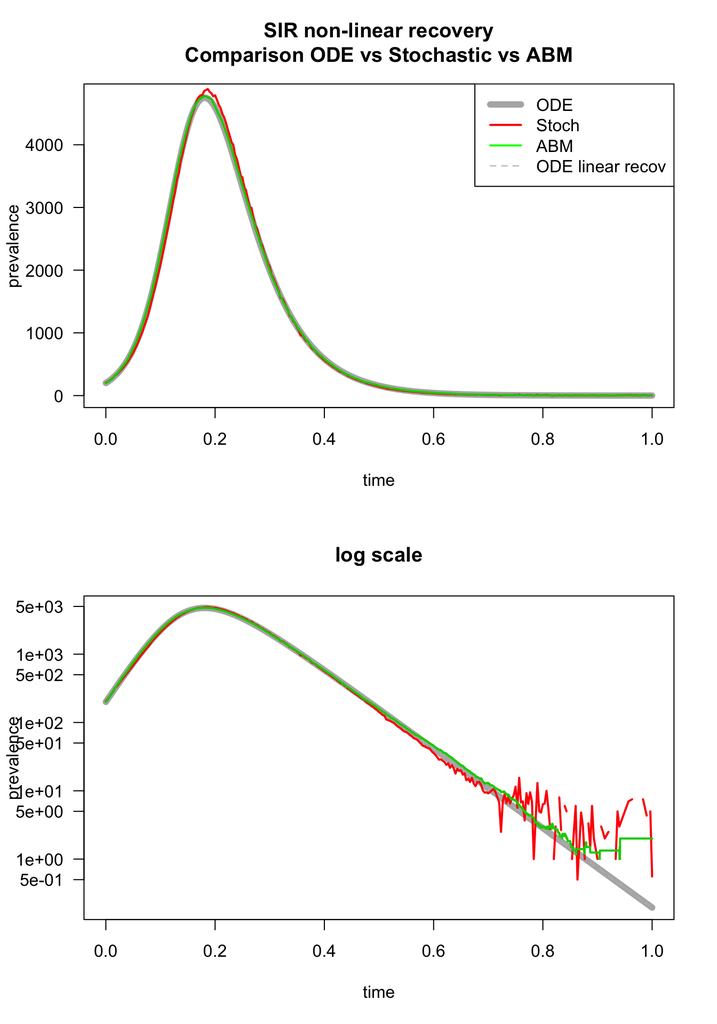

The prevalence curves match: the ABM has passed this basic test.

## Analysis of distributions

Let’s look at the distribution of the infectious period under several $K$ recovery functions.

Let’s set the main parameters for the simulation:

```r
horizon         <- 365  # in days
pop.size        <- 1E4
infectious.mean <- 4.5  # in days
latent.mean     <- 3.5  # in days
R0              <- 3.00

# Number of compartments in E and I:
nE    <- 1
nI    <- 1

n.CPU <- 3           # CPU used
n.MC  <- 2 * n.CPU   # Monte carlo iterations per CPU

K.list <- list()

K.list[[1]] <- list(Kfct = 'one',
                    Kfct_prm = c(0))

K.list[[2]] <- list(Kfct = 'sqrt',
                    Kfct_prm = c(0))

K.list[[3]] <- list(Kfct = 'lin',
                    Kfct_prm = c(0))

K.list[[4]] <- list(Kfct = 'exp',
                    Kfct_prm = c(2))

K.list[[5]] <- list(Kfct = 'pow',
                    Kfct_prm = c(3))

K.list[[6]] <- list(Kfct = 'inv',
                    Kfct_prm = c(2, -5))
```

### Generation interval distributions

For the backward generation interval distributions, the mean GI seems to be increased under all transformations of the recovery process (all curves are above `one`). Note that for the “standard” case `K=one`, we find the same shape as in Champredon & Dushoff RSPB 2015. It is also remarkable that the square root recovery streches the GIs and also the epidemic.

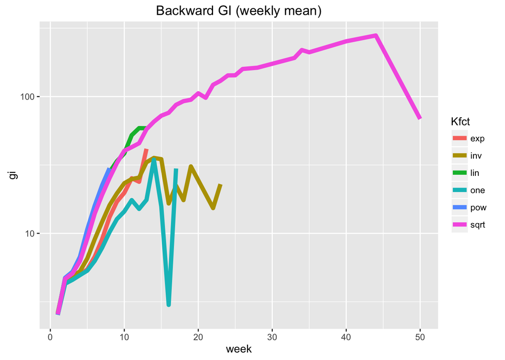

Looking at the evolution of GI distributions is less clear to see the differences:

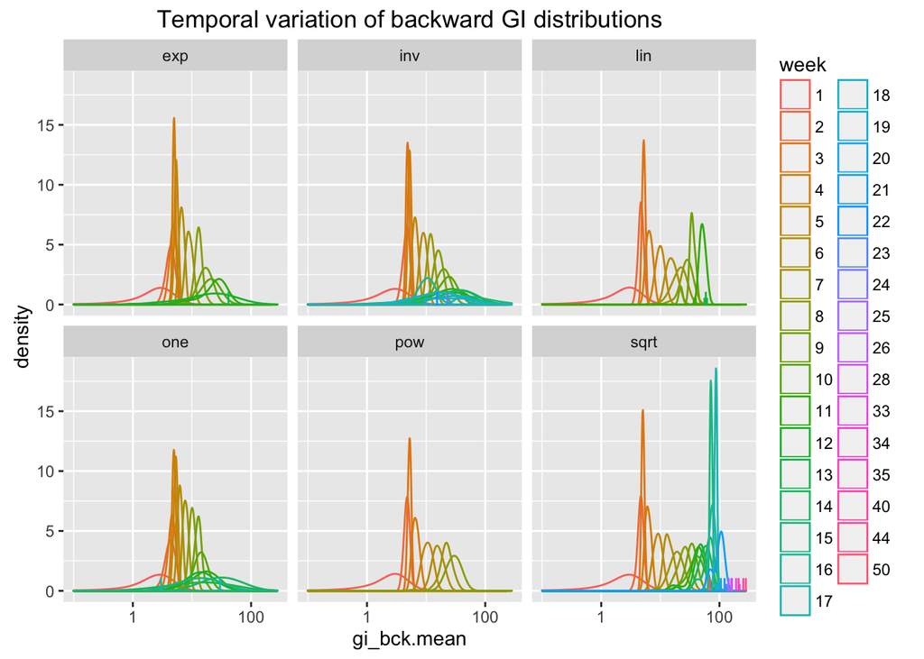

### Infectiousness duration distributions

Patterns for the mean duration of infectiousness are more noisy.

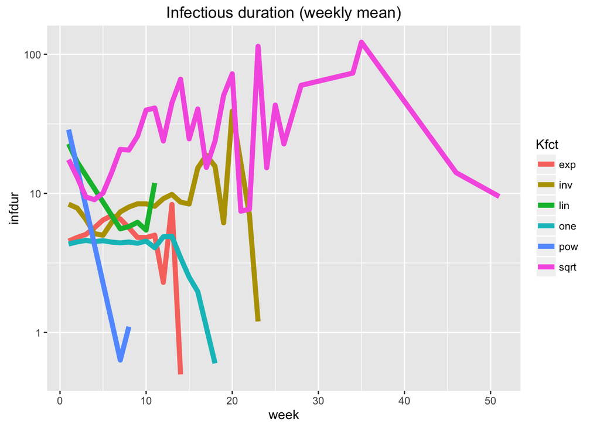

Unlike the GIs, it is easier to see what’s going on by looking directly at the infectious duration distributions directly. Note the black dashed line is the exponential density, which must match the `K=one` case when `nI=1`:

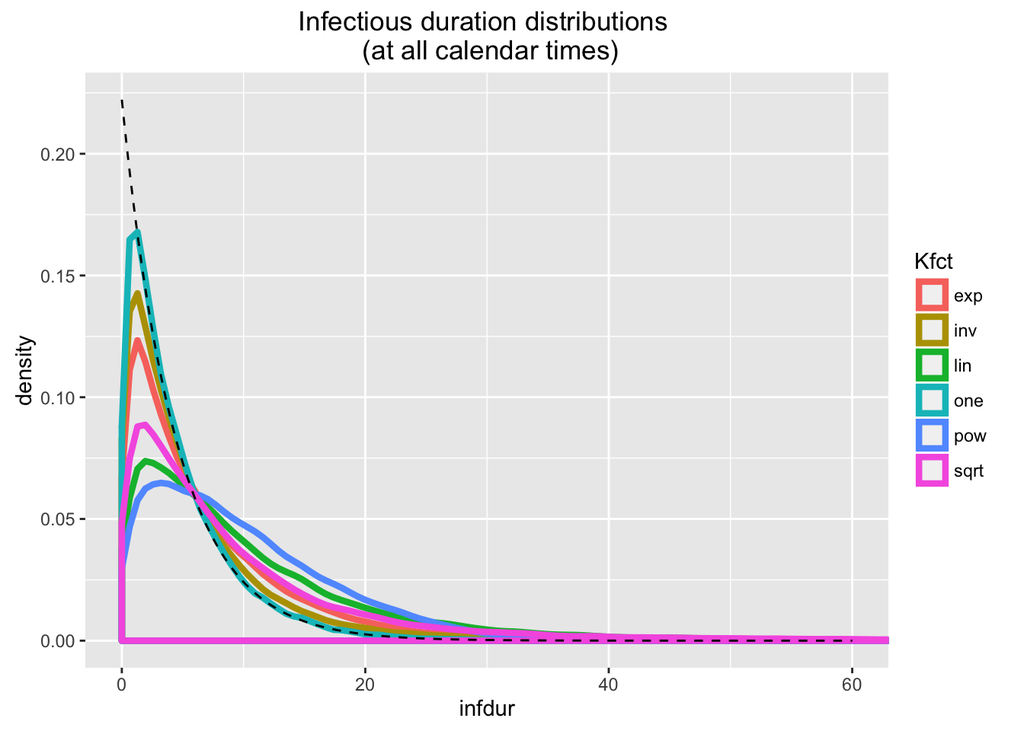

There seems to be a remarkable point (around infdur=6) where the shape for $K$ does not affect the density. Can we find it analitycally???

Now, looking at how these distributions evolve with calendar time:

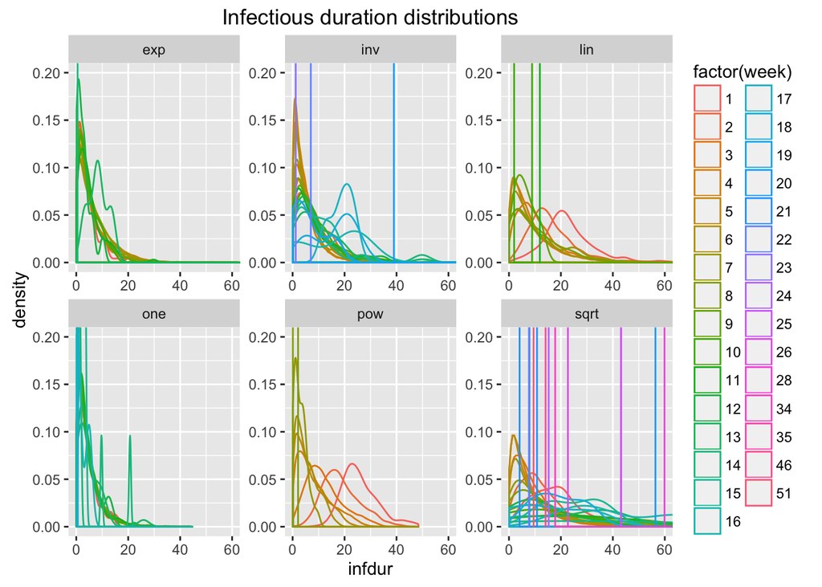

It is not clear because of the noise from the weeks where there is no/very little data.